# Chapter 12

The aim of these exercises is to start getting familiar with mixed models, and in these exercises we’ll be focused on models with correlated data.

For each of the examples below, you should follow the sequence we’ve used previously:

1. What is the biological question?
2. Is the predictor continuous or categorical?
3. Write out the linear model corresponding to this question.
4. What distribution do you expect the response variable to follow?
5. What are the assumptions behind the statistical model you’ll fit?
   1. Are those assumptions satisfied?
6. Fit the model
   1. How will you assess whether the model fits well?
   2. Can you detect an effect of the predictor?
   3. How do you measure the effect?
7. What do you conclude (including any cautions)

#### Things to look out for

In fitting these models, we’ll need to make the initial checklist more complex:

- as well as classifying a predictor as continuous or categorical, think clearly about whether it is random or fixed
- think about the structure of the data; are all observations of the response variable independent of each other, or are they linked in some way? If they are linked, how do de account for that linkage in specifying and fitting a statistical model?
- When there are random effects, assumptions can be more extensive. We’re usually interested in the fixed effects, and different fixed effects can have different assumptions. This is particularly the case with nested designs.

## When there are correlated effects, we might need to be aware of additional assumptions.

## A Straightforward, with a chance to be complex

Let’s start with an example we mentioned briefly in Chapter 12, and work through the data analysis. Allen and Marshall (2014) studied the effects of egg size on larval characteristics of a marine tubeworm. They allocated eggs from a group of large or small female tubeworms to ten jars for each egg size. These eggs were fertilized, and after the embryos hatched, the proportion of larvae that had settled and metamorphosed was recorded for each jar every three days for 15 days. The question here is about maternal effects (using size as a proxy for energy reserves available) on offspring performance (time to settle and initiate metamorphosis from larval form to adult form).

Start by following the steps we’ve used for other chapters, so you’re clear on the questions the details of the design, and the applicable statistical model.

We’ll start by reading in the data and taking a quick look at it.

```
setting contr.sum globally: options(contrasts=c('contr.sum', 'contr.poly'))
```

| sizeclass | jar | day | day1 | perc |
| --- | --- | --- | --- | --- |
| b | 1 | 3 | 3 | 0.052 |
| b | 2 | 3 | 3 | 0.096 |
| b | 3 | 3 | 3 | 0.052 |
| b | 4 | 3 | 3 | 0.078 |
| b | 5 | 3 | 3 | 0.081 |
| b | 6 | 3 | 3 | 0.058 |
| b | 7 | 3 | 3 | 0.091 |
| b | 8 | 3 | 3 | 0.064 |
| b | 9 | 3 | 3 | 0.070 |
| b | 10 | 3 | 3 | 0.071 |

In this data file:

- *sizeclass* describes the mothers, b(ig) or s(mall)
- *jar* is numbered 1-20, but could as easily be a, b, c, etc. or any arbitrary label. We treated it as a character variable just so we don’t be fooled into thinking the numbers mean anything quantitative.
- *day* represents sampling times. We’ve made it categorical, ready for some analyses.
- *day1* represents sampling times, but as a continuous variable
- *perc* is the proportion of larvae settled and undergoing or completed metamorphosis
- *lperc* is log-transformed *perc*. Allen & Marshall used this transformation.

### Start by taking a close look at the data and thinking about assumptions

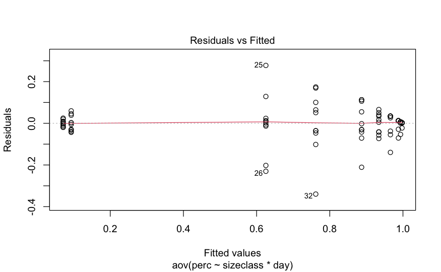

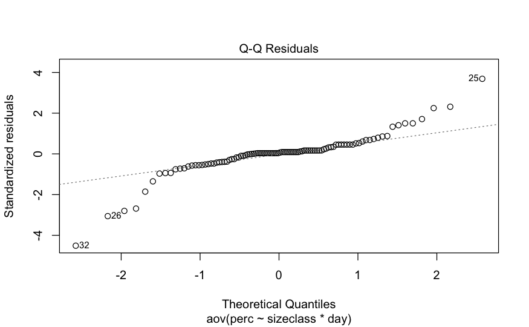

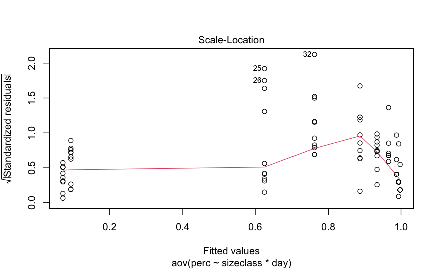

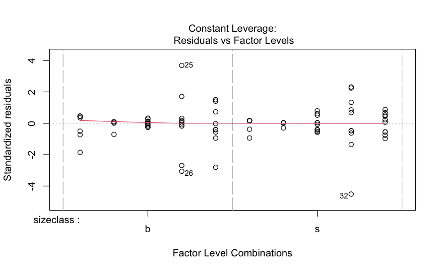

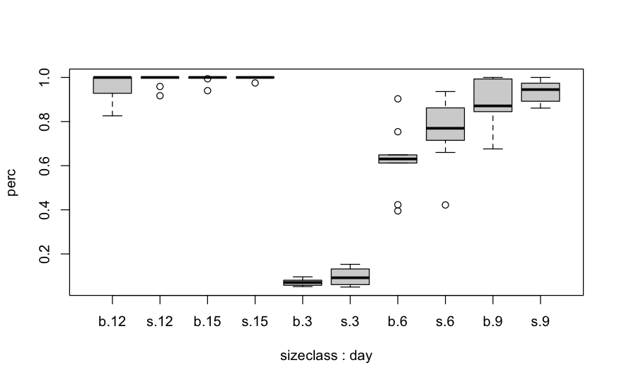

| sizeclass | day | N | perc | sd | se | ci |
| --- | --- | --- | --- | --- | --- | --- |
| b | 12 | 10 | 0.9657 | 0.059329682 | 0.018761693 | 0.042441897 |
| b | 15 | 10 | 0.9934 | 0.018857359 | 0.005963221 | 0.013489742 |
| b | 3 | 10 | 0.0713 | 0.015326448 | 0.004846648 | 0.010963880 |
| b | 6 | 10 | 0.6253 | 0.144789541 | 0.045786473 | 0.103576198 |
| b | 9 | 10 | 0.8870 | 0.101647539 | 0.032143774 | 0.072714269 |
| s | 12 | 10 | 0.9876 | 0.027953135 | 0.008839558 | 0.019996468 |
| s | 15 | 10 | 0.9975 | 0.007905694 | 0.002500000 | 0.005655393 |
| s | 3 | 10 | 0.0933 | 0.037288813 | 0.011791758 | 0.026674810 |
| s | 6 | 10 | 0.7617 | 0.151414846 | 0.047881578 | 0.108315656 |
| s | 9 | 10 | 0.9340 | 0.049497475 | 0.015652476 | 0.035408360 |

**If you have concerns about the raw data, would those concerns be eased if you used log-transformed responses?**

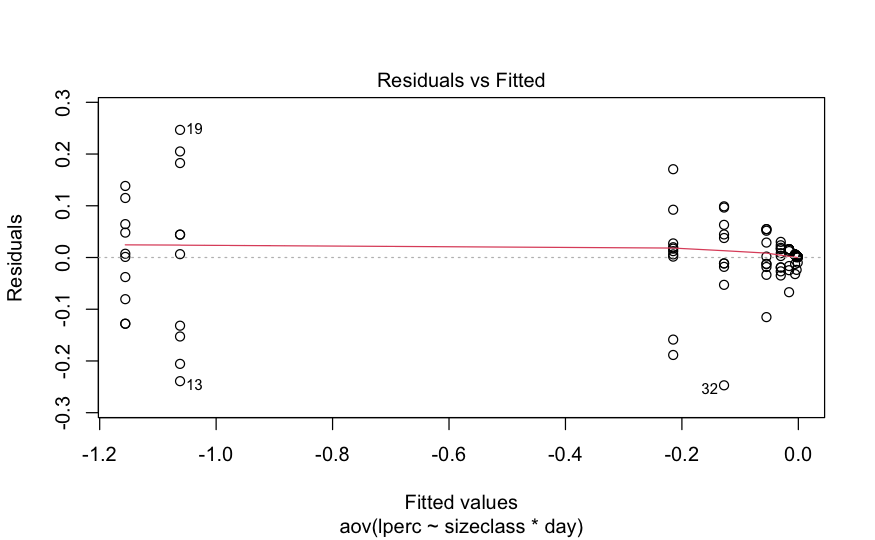

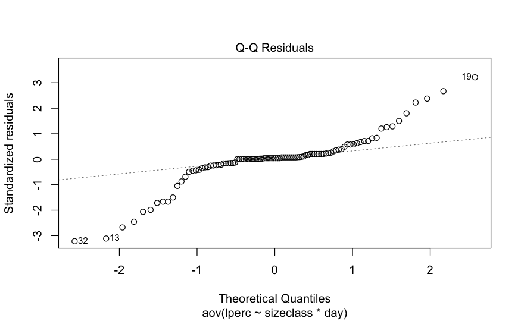

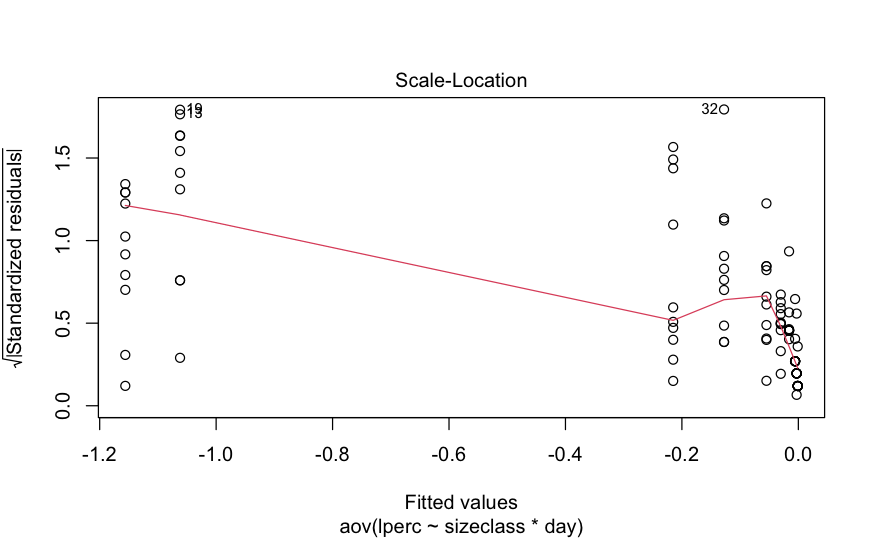

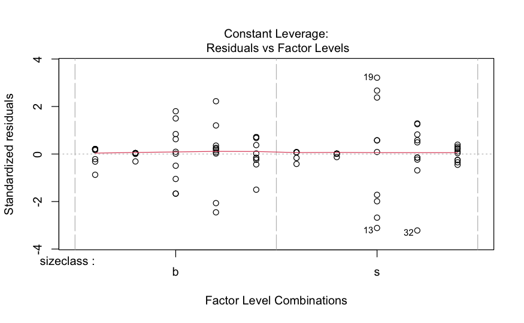

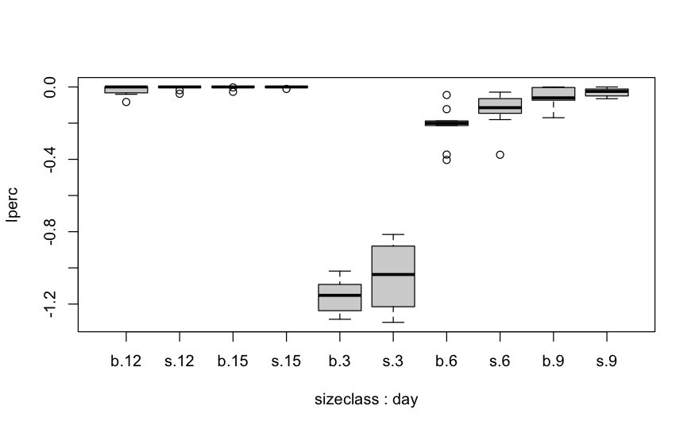

| sizeclass | day | N | lperc | sd | se | ci |
| --- | --- | --- | --- | --- | --- | --- |
| b | 12 | 10 | -0.015944193 | 0.027996436 | 0.008853250 | 0.020027444 |
| b | 15 | 10 | -0.002948576 | 0.008445921 | 0.002670835 | 0.006041848 |
| b | 3 | 10 | -1.156013671 | 0.094025554 | 0.029733491 | 0.067261829 |
| b | 6 | 10 | -0.214984137 | 0.105383902 | 0.033325316 | 0.075387102 |
| b | 9 | 10 | -0.054810843 | 0.052253073 | 0.016523872 | 0.037379596 |
| s | 12 | 10 | -0.005581206 | 0.012627709 | 0.003993232 | 0.009033319 |
| s | 15 | 10 | -0.001099538 | 0.003477046 | 0.001099538 | 0.002487329 |
| s | 3 | 10 | -1.061982113 | 0.176470596 | 0.055804902 | 0.126239459 |
| s | 6 | 10 | -0.127616094 | 0.100512568 | 0.031784865 | 0.071902359 |
| s | 9 | 10 | -0.030206429 | 0.023154855 | 0.007322208 | 0.016563985 |

### Let’s start with a straightforward, conventional model

*First analyse with day as categorical factor (using the predictor day)*

Think of a couple of ways you could look at this predictor

```
Error: jar
          Df  Sum Sq Mean Sq F value Pr(>F)
sizeclass  1 0.05355 0.05355   6.097 0.0238 *
Residuals 18 0.15809 0.00878
---
Signif. codes:  0 ‘***’ 0.001 ‘**’ 0.01 ‘*’ 0.05 ‘.’ 0.1 ‘ ’ 1

Error: Within
              Df Sum Sq Mean Sq F value Pr(>F)
day            4 11.694  2.9236 514.581 <2e-16 ***
sizeclass:day  4  0.055  0.0139   2.439 0.0546 .
Residuals     72  0.409  0.0057
---
Signif. codes:  0 ‘***’ 0.001 ‘**’ 0.01 ‘*’ 0.05 ‘.’ 0.1 ‘ ’ 1

Error: jar
          Df  Sum Sq Mean Sq F value Pr(>F)
sizeclass  1 0.05355 0.05355   6.097 0.0238 *
Residuals 18 0.15809 0.00878
---
Signif. codes:  0 ‘***’ 0.001 ‘**’ 0.01 ‘*’ 0.05 ‘.’ 0.1 ‘ ’ 1

Error: Within
                           Df Sum Sq Mean Sq F value   Pr(>F)
day                         4 11.694   2.924 514.581  < 2e-16 ***
  day: linear               1  0.377   0.377  66.382 8.13e-12 ***
  day: quadratic            1  5.270   5.270 927.650  < 2e-16 ***
  day: cubic                1  0.578   0.578 101.796 2.02e-15 ***
sizeclass:day               4  0.055   0.014   2.439   0.0546 .
  sizeclass:day: linear     1  0.017   0.017   2.931   0.0912 .
  sizeclass:day: quadratic  1  0.001   0.001   0.137   0.7123
  sizeclass:day: cubic      1  0.029   0.029   5.048   0.0277 *
Residuals                  72  0.409   0.006
---
Signif. codes:  0 ‘***’ 0.001 ‘**’ 0.01 ‘*’ 0.05 ‘.’ 0.1 ‘ ’ 1
```

```
$ANOVA
         Effect DFn DFd         SSn       SSd           F            p p<.05        ges
1   (Intercept)   1  18 53.53556224 0.1580930 6095.400304 3.088576e-24     * 0.98951702
2     sizeclass   1  18  0.05354596 0.1580930    6.096584 2.378373e-02     * 0.08626653
3           day   4  72 11.69427206 0.4090648  514.580812 3.922941e-52     * 0.95374456
4 sizeclass:day   4  72  0.05542594 0.4090648    2.438897 5.460958e-02       0.08902568

$`Mauchly's Test for Sphericity`
         Effect          W            p p<.05
3           day 0.01826309 1.381999e-10     *
4 sizeclass:day 0.01826309 1.381999e-10     *

$`Sphericity Corrections`
         Effect       GGe        p[GG] p[GG]<.05       HFe        p[HF] p[HF]<.05
3           day 0.3908913 9.426762e-22         * 0.4214378 2.795198e-23         *
4 sizeclass:day 0.3908913 1.160297e-01           0.4214378 1.118338e-01
```

#### What do you conclude about maternal effects? Illustrate your results graphically

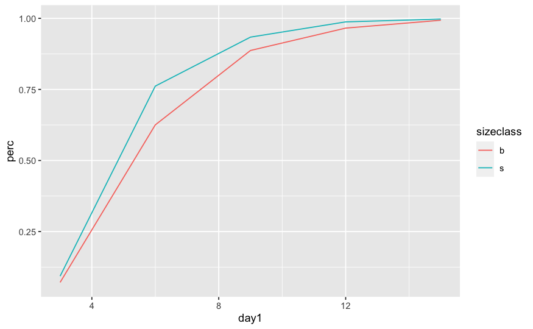

```
Linear mixed model fit by REML. t-tests use Satterthwaite's method ['lmerModLmerTest']
Formula: perc ~ sizeclass * day + (1 | jar)
   Data: allen

REML criterion at convergence: -168.9

Scaled residuals:
    Min      1Q  Median      3Q     Max
-4.2499 -0.3218  0.0458  0.3235  3.2707

Random effects:
 Groups   Name        Variance  Std.Dev.
 jar      (Intercept) 0.0006203 0.02491
 Residual             0.0056815 0.07538
Number of obs: 100, groups:  jar, 20

Fixed effects:
                  Estimate Std. Error        df t value Pr(>|t|)
(Intercept)       0.731680   0.009372 18.000000  78.073  < 2e-16 ***
sizeclass1       -0.023140   0.009372 18.000000  -2.469   0.0238 *
day.L            -0.137322   0.016854 72.000000  -8.148 8.13e-12 ***
day.Q             0.513342   0.016854 72.000000  30.457  < 2e-16 ***
day.C             0.170051   0.016854 72.000000  10.089 2.02e-15 ***
day^4            -0.522895   0.016854 72.000000 -31.024  < 2e-16 ***
sizeclass1:day.L -0.028856   0.016854 72.000000  -1.712   0.0912 .
sizeclass1:day.Q  0.006241   0.016854 72.000000   0.370   0.7123
sizeclass1:day.C  0.037868   0.016854 72.000000   2.247   0.0277 *
sizeclass1:day^4  0.021580   0.016854 72.000000   1.280   0.2045
---
Signif. codes:  0 ‘***’ 0.001 ‘**’ 0.01 ‘*’ 0.05 ‘.’ 0.1 ‘ ’ 1

Correlation of Fixed Effects:
            (Intr) szcls1 day.L day.Q day.C day^4 sz1:.L sz1:.Q sz1:.C
sizeclass1  0.000
day.L       0.000  0.000
day.Q       0.000  0.000  0.000
day.C       0.000  0.000  0.000 0.000
day^4       0.000  0.000  0.000 0.000 0.000
szclss1:d.L 0.000  0.000  0.000 0.000 0.000 0.000
szclss1:d.Q 0.000  0.000  0.000 0.000 0.000 0.000 0.000
szclss1:d.C 0.000  0.000  0.000 0.000 0.000 0.000 0.000  0.000
szclss1:d^4 0.000  0.000  0.000 0.000 0.000 0.000 0.000  0.000  0.000
Type III Analysis of Variance Table with Kenward-Roger's method
               Sum Sq Mean Sq NumDF DenDF  F value  Pr(>F)
sizeclass      0.0346 0.03464     1    18   6.0966 0.02378 *
day           11.6943 2.92357     4    72 514.5808 < 2e-16 ***
sizeclass:day  0.0554 0.01386     4    72   2.4389 0.05461 .
---
Signif. codes:  0 ‘***’ 0.001 ‘**’ 0.01 ‘*’ 0.05 ‘.’ 0.1 ‘ ’ 1
Analysis of Deviance Table (Type III Wald chisquare tests)

Response: perc
                  Chisq Df Pr(>Chisq)
(Intercept)   6095.4003  1    < 2e-16 ***
sizeclass        6.0966  1    0.01354 *
day           2058.3232  4    < 2e-16 ***
sizeclass:day    9.7556  4    0.04475 *
---
Signif. codes:  0 ‘***’ 0.001 ‘**’ 0.01 ‘*’ 0.05 ‘.’ 0.1 ‘ ’ 1
```

```
Computing profile confidence intervals ...
```

```
                        2.5 %       97.5 %
.sig01           0.0000000000 2.152045e-03
.sigma           0.0038082185 7.089593e-03
(Intercept)      0.5089155285 5.624653e-01
sizeclass1       0.0017170120 2.345619e-05
day.L            0.0285748030 1.115199e-02
day.Q            0.2319608156 2.970914e-01
day.C            0.0191358961 4.071130e-02
day^4            0.3075961490 2.412535e-01
sizeclass1:day.L 0.0036692953 8.197578e-06
sizeclass1:day.Q 0.0006491476 1.440922e-03
sizeclass1:day.C 0.0000378145 4.842378e-03
sizeclass1:day^4 0.0001028008 2.840760e-03
```

```
Error: number of observations (=100) <= number of random effects (=100) for term (day | jar); the random-effects parameters and the residual variance (or scale parameter) are probably unidentifiable
```

```
Linear mixed-effects model fit by REML
  Data: allen
```

|  | AIC | BIC | logLik |
| --- | --- | --- | --- |
|  | -144.9233 | -114.9256 | 84.46165 |

```
Random effects:
 Formula: ~1 | jar
        (Intercept)   Residual
StdDev:  0.02490578 0.07537543

Fixed effects:  perc ~ sizeclass * day
```

|  | Value | Std.Error | DF | t-value | p-value |
| --- | --- | --- | --- | --- | --- |
| (Intercept) | 0.7316800 | 0.009371736 | 72 | 78.07304 | 0.0000 |
| sizeclass1 | -0.0231400 | 0.009371736 | 18 | -2.46913 | 0.0238 |
| day.L | -0.1373219 | 0.016854459 | 72 | -8.14751 | 0.0000 |
| day.Q | 0.5133420 | 0.016854459 | 72 | 30.45734 | 0.0000 |
| day.C | 0.1700515 | 0.016854459 | 72 | 10.08941 | 0.0000 |
| day^4 | -0.5228946 | 0.016854459 | 72 | -31.02411 | 0.0000 |
| sizeclass1:day.L | -0.0288558 | 0.016854459 | 72 | -1.71206 | 0.0912 |
| sizeclass1:day.Q | 0.0062405 | 0.016854459 | 72 | 0.37026 | 0.7123 |
| sizeclass1:day.C | 0.0378683 | 0.016854459 | 72 | 2.24678 | 0.0277 |
| sizeclass1:day^4 | 0.0215799 | 0.016854459 | 72 | 1.28036 | 0.2045 |

```
 Correlation:
                 (Intr) szcls1 day.L day.Q day.C day^4 sz1:.L sz1:.Q sz1:.C
sizeclass1       0
day.L            0      0
day.Q            0      0      0
day.C            0      0      0     0
day^4            0      0      0     0     0
sizeclass1:day.L 0      0      0     0     0     0
sizeclass1:day.Q 0      0      0     0     0     0     0
sizeclass1:day.C 0      0      0     0     0     0     0      0
sizeclass1:day^4 0      0      0     0     0     0     0      0      0

Standardized Within-Group Residuals:
        Min          Q1         Med          Q3         Max
-4.24994739 -0.32180883  0.04582493  0.32345474  3.27073515

Number of Observations: 100
Number of Groups: 20
```

|  | numDF | denDF | F-value | p-value |
| --- | --- | --- | --- | --- |
| (Intercept) | 1 | 72 | 6095.400 | <.0001 |
| sizeclass | 1 | 18 | 6.097 | 0.0238 |
| day | 4 | 72 | 514.581 | <.0001 |
| sizeclass:day | 4 | 72 | 2.439 | 0.0546 |

```
Analysis of Deviance Table (Type III tests)

Response: perc
                  Chisq Df Pr(>Chisq)
(Intercept)   6095.4003  1    < 2e-16 ***
sizeclass        6.0966  1    0.01354 *
day           2058.3233  4    < 2e-16 ***
sizeclass:day    9.7556  4    0.04475 *
---
Signif. codes:  0 ‘***’ 0.001 ‘**’ 0.01 ‘*’ 0.05 ‘.’ 0.1 ‘ ’ 1
```

You may (hopefully you did!) have noticed some quite different variances between groups. One way we could deal with this is to allow group-specific variances. For interest, let’s use this approach and see if this model fits better

```
Linear mixed-effects model fit by REML
  Data: allen
```

|  | AIC | BIC | logLik |
| --- | --- | --- | --- |
|  | -249.4384 | -196.9424 | 145.7192 |

```
Random effects:
 Formula: ~1 | jar
        (Intercept)   Residual
StdDev: 0.009304136 0.01039594

Variance function:
 Structure: Different standard deviations per stratum
 Formula: ~1 | sizeclass * day
 Parameter estimates:
         b*3          b*6          b*9         b*12         b*15          s*3          s*6          s*9         s*12         s*15
1.000000e+00 1.364725e+01 9.468084e+00 5.156349e+00 1.417099e+00 3.928516e+00 1.469753e+01 4.597833e+00 2.044279e+00 2.403362e-05
Fixed effects:  perc ~ sizeclass * day
```

|  | Value | Std.Error | DF | t-value | p-value |
| --- | --- | --- | --- | --- | --- |
| (Intercept) | 0.7316800 | 0.008068126 | 72 | 90.68772 | 0.0000 |
| sizeclass1 | -0.0231400 | 0.008068126 | 18 | -2.86808 | 0.0102 |
| day.L | -0.1373219 | 0.016192985 | 72 | -8.48033 | 0.0000 |
| day.Q | 0.5133420 | 0.014141455 | 72 | 36.30051 | 0.0000 |
| day.C | 0.1700515 | 0.021798298 | 72 | 7.80114 | 0.0000 |
| day^4 | -0.5228946 | 0.016672342 | 72 | -31.36300 | 0.0000 |
| sizeclass1:day.L | -0.0288558 | 0.016192985 | 72 | -1.78199 | 0.0790 |
| sizeclass1:day.Q | 0.0062405 | 0.014141455 | 72 | 0.44129 | 0.6603 |
| sizeclass1:day.C | 0.0378683 | 0.021798298 | 72 | 1.73721 | 0.0866 |
| sizeclass1:day^4 | 0.0215799 | 0.016672342 | 72 | 1.29435 | 0.1997 |

```
 Correlation:
                 (Intr) szcls1 day.L  day.Q  day.C  day^4  sz1:.L sz1:.Q sz1:.C
sizeclass1        0.081
day.L             0.733  0.079
day.Q            -0.195  0.302 -0.080
day.C            -0.700  0.107 -0.402  0.712
day^4            -0.661  0.055 -0.545  0.623  0.922
sizeclass1:day.L  0.079  0.733  0.346  0.216  0.182  0.083
sizeclass1:day.Q  0.302 -0.195  0.216  0.268  0.021  0.089 -0.080
sizeclass1:day.C  0.107 -0.700  0.182  0.021 -0.011 -0.058 -0.402  0.712
sizeclass1:day^4  0.055 -0.661  0.083  0.089 -0.058 -0.121 -0.545  0.623  0.922

Standardized Within-Group Residuals:
        Min          Q1         Med          Q3         Max
-2.37498163 -0.31217241  0.01825073  0.53535176  1.91448689

Number of Observations: 100
Number of Groups: 20
```

|  | Model | df | AIC | BIC | logLik | Test | L.Ratio | p-value |
| --- | --- | --- | --- | --- | --- | --- | --- | --- |
| allen1.lme | 1 | 12 | -144.9233 | -114.9256 | 84.46165 |  |  |  |
| allen2.lme | 2 | 21 | -249.4384 | -196.9424 | 145.71918 | 1 vs 2 | 122.5151 | <.0001 |

|  | numDF | denDF | F-value | p-value |
| --- | --- | --- | --- | --- |
| (Intercept) | 1 | 72 | 8224.263 | <.0001 |
| sizeclass | 1 | 18 | 8.226 | 0.0102 |
| day | 4 | 72 | 4212.112 | <.0001 |
| sizeclass:day | 4 | 72 | 1.862 | 0.1265 |

```
Analysis of Deviance Table (Type III tests)

Response: perc
                   Chisq Df Pr(>Chisq)
(Intercept)    8224.2630  1    < 2e-16 ***
sizeclass         8.2259  1    0.00413 **
day           16848.4461  4    < 2e-16 ***
sizeclass:day     7.4478  4    0.11403
---
Signif. codes:  0 ‘***’ 0.001 ‘**’ 0.01 ‘*’ 0.05 ‘.’ 0.1 ‘ ’ 1
```

Do your conclusions change?

### Extend yourself: treat time as a continuous predictor (use day1)

**Think about how you’d specify the model. Describe the random slopes and random intercepts models, and then fit them.**

*Is the random intercepts approach needed?*

```
Error: jar
          Df  Sum Sq Mean Sq F value Pr(>F)
sizeclass  1 0.05355 0.05355   6.097 0.0238 *
Residuals 18 0.15809 0.00878
---
Signif. codes:  0 ‘***’ 0.001 ‘**’ 0.01 ‘*’ 0.05 ‘.’ 0.1 ‘ ’ 1

Error: Within
               Df Sum Sq Mean Sq F value Pr(>F)
day1            1  8.900   8.900 213.727 <2e-16 ***
sizeclass:day1  1  0.011   0.011   0.271  0.604
Residuals      78  3.248   0.042
---
Signif. codes:  0 ‘***’ 0.001 ‘**’ 0.01 ‘*’ 0.05 ‘.’ 0.1 ‘ ’ 1
```

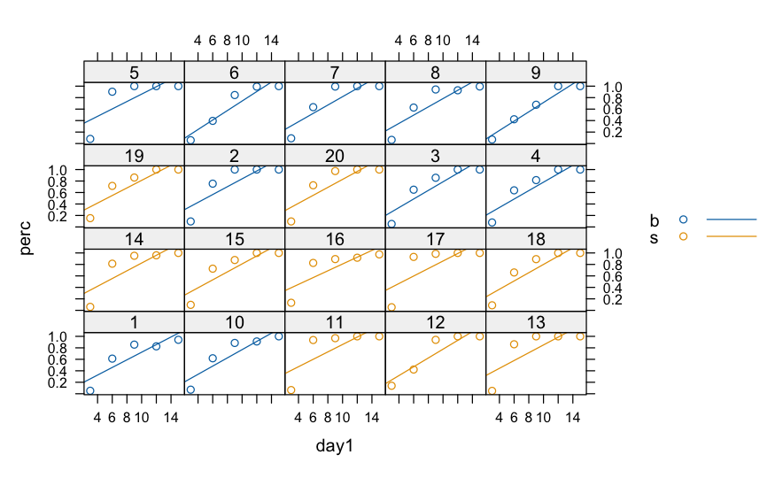

```
Call:
  Model: perc ~ day1 | jar
   Data: allen

Coefficients:
   (Intercept)
   Estimate Std. Error     t value  Pr(>|t|)
1    0.0602  0.2423175  0.24843436 0.8046467
10   0.0517  0.2423175  0.21335642 0.8317723
11   0.2128  0.2423175  0.87818657 0.3833457
12   0.0100  0.2423175  0.04126817 0.9672191
13   0.1710  0.2423175  0.70568563 0.4831146
14   0.1496  0.2423175  0.61737176 0.5393256
15   0.1152  0.2423175  0.47540927 0.6362215
16   0.2155  0.2423175  0.88932897 0.3773781
```

[output cut: 36 more lines]

```
boundary (singular) fit: see help('isSingular')
```

```
Linear mixed model fit by REML. t-tests use Satterthwaite's method ['lmerModLmerTest']
Formula: perc ~ sizeclass * day1 + (day1 | jar)
   Data: allen

REML criterion at convergence: -23.9

Scaled residuals:
    Min      1Q  Median      3Q     Max
-1.5819 -0.8584  0.2217  0.7688  2.1922

Random effects:
 Groups   Name        Variance  Std.Dev.  Corr
 jar      (Intercept) 7.818e-18 2.796e-09
          day1        2.123e-17 4.608e-09 -1.00
 Residual             3.548e-02 1.884e-01
Number of obs: 100, groups:  jar, 20

Fixed effects:
                 Estimate Std. Error        df t value Pr(>|t|)
(Intercept)      0.098845   0.044174 96.000000   2.238   0.0276 *
sizeclass1      -0.045685   0.044174 96.000000  -1.034   0.3036
day1             0.070315   0.004440 96.000000  15.838   <2e-16 ***
sizeclass1:day1  0.002505   0.004440 96.000000   0.564   0.5739
---
Signif. codes:  0 ‘***’ 0.001 ‘**’ 0.01 ‘*’ 0.05 ‘.’ 0.1 ‘ ’ 1

Correlation of Fixed Effects:
            (Intr) szcls1 day1
sizeclass1   0.000
day1        -0.905  0.000
szclss1:dy1  0.000 -0.905  0.000
optimizer (nloptwrap) convergence code: 0 (OK)
boundary (singular) fit: see help('isSingular')
```

```
boundary (singular) fit: see help('isSingular')
```

```
Linear mixed model fit by REML. t-tests use Satterthwaite's method ['lmerModLmerTest']
Formula: perc ~ sizeclass * day1 + (1 | jar)
   Data: allen

REML criterion at convergence: -23.9

Scaled residuals:
    Min      1Q  Median      3Q     Max
-1.5819 -0.8584  0.2217  0.7688  2.1922

Random effects:
 Groups   Name        Variance Std.Dev.
 jar      (Intercept) 0.00000  0.0000
 Residual             0.03548  0.1884
Number of obs: 100, groups:  jar, 20

Fixed effects:
                 Estimate Std. Error        df t value Pr(>|t|)
(Intercept)      0.098845   0.044174 96.000000   2.238   0.0276 *
sizeclass1      -0.045685   0.044174 96.000000  -1.034   0.3036
day1             0.070315   0.004440 96.000000  15.838   <2e-16 ***
sizeclass1:day1  0.002505   0.004440 96.000000   0.564   0.5739
---
Signif. codes:  0 ‘***’ 0.001 ‘**’ 0.01 ‘*’ 0.05 ‘.’ 0.1 ‘ ’ 1

Correlation of Fixed Effects:
            (Intr) szcls1 day1
sizeclass1   0.000
day1        -0.905  0.000
szclss1:dy1  0.000 -0.905  0.000
optimizer (nloptwrap) convergence code: 0 (OK)
boundary (singular) fit: see help('isSingular')
```

```
boundary (singular) fit: see help('isSingular')
```

```
ANOVA-like table for random-effects: Single term deletions

Model:
perc ~ sizeclass + day1 + (day1 | jar) + sizeclass:day1
                     npar logLik     AIC         LRT Df Pr(>Chisq)
<none>                  8 11.944  -7.888
day1 in (day1 | jar)    6 11.944 -11.888 -4.0821e-12  2          1
```

```
refitting model(s) with ML (instead of REML)
```

```
Data: allen
Models:
allen3.lmer: perc ~ sizeclass * day1 + (1 | jar)
allen2.lmer: perc ~ sizeclass * day1 + (day1 | jar)
            npar     AIC     BIC logLik deviance Chisq Df Pr(>Chisq)
allen3.lmer    6 -42.175 -26.544 27.088  -54.175
allen2.lmer    8 -38.175 -17.334 27.088  -54.175     0  2          1
Type III Analysis of Variance Table with Satterthwaite's method
               Sum Sq Mean Sq NumDF DenDF  F value Pr(>F)
sizeclass      0.0379  0.0379     1    96   1.0696 0.3036
day1           8.8996  8.8996     1    96 250.8388 <2e-16 ***
sizeclass:day1 0.0113  0.0113     1    96   0.3184 0.5739
---
Signif. codes:  0 ‘***’ 0.001 ‘**’ 0.01 ‘*’ 0.05 ‘.’ 0.1 ‘ ’ 1
Analysis of Deviance Table (Type III Wald chisquare tests)

Response: perc
                  Chisq Df Pr(>Chisq)
(Intercept)      5.0069  1    0.02525 *
sizeclass        1.0696  1    0.30104
day1           250.8388  1    < 2e-16 ***
sizeclass:day1   0.3184  1    0.57260
---
Signif. codes:  0 ‘***’ 0.001 ‘**’ 0.01 ‘*’ 0.05 ‘.’ 0.1 ‘ ’ 1
```

#### Last, if you want to extend yourself a bit, Let’s look at accounting for some of the heterogeneity in variances by allowing covariances to differ (we’ll use AR1)

Now run as mixed effects random intercept with nlme - use day1 for continuous (not factor) and allow covariances to differ.

**Does this approach give us a model that fits better?

|  | Model | df | AIC | BIC | logLik | Test | L.Ratio | p-value |
| --- | --- | --- | --- | --- | --- | --- | --- | --- |
| allen3.lme | 1 | 6 | -11.88804 | 3.498050 | 11.94402 |  |  |  |
| allen4.lme | 2 | 7 | -9.89915 | 8.051288 | 11.94957 | 1 vs 2 | 0.01111035 | 0.9161 |

```
Linear mixed-effects model fit by REML
  Data: allen
```

|  | AIC | BIC | logLik |
| --- | --- | --- | --- |
|  | -11.88804 | 3.49805 | 11.94402 |

```
Random effects:
 Formula: ~1 | jar
         (Intercept)  Residual
StdDev: 2.750188e-06 0.1883592

Fixed effects:  perc ~ sizeclass * day1
```

|  | Value | Std.Error | DF | t-value | p-value |
| --- | --- | --- | --- | --- | --- |
| (Intercept) | 0.098845 | 0.04417415 | 78 | 2.237621 | 0.0281 |
| sizeclass1 | -0.045685 | 0.04417415 | 18 | -1.034202 | 0.3147 |
| day1 | 0.070315 | 0.00443967 | 78 | 15.837893 | 0.0000 |
| sizeclass1:day1 | 0.002505 | 0.00443967 | 78 | 0.564231 | 0.5742 |

```
 Correlation:
                (Intr) szcls1 day1
sizeclass1       0.000
day1            -0.905  0.000
sizeclass1:day1  0.000 -0.905  0.000

Standardized Within-Group Residuals:
       Min         Q1        Med         Q3        Max
-1.5818712 -0.8583600  0.2216510  0.7687705  2.1921945

Number of Observations: 100
Number of Groups: 20
```

|  | numDF | denDF | F-value | p-value |
| --- | --- | --- | --- | --- |
| (Intercept) | 1 | 78 | 5.00695 | 0.0281 |
| sizeclass | 1 | 18 | 1.06957 | 0.3147 |
| day1 | 1 | 78 | 250.83884 | <.0001 |
| sizeclass:day1 | 1 | 78 | 0.31836 | 0.5742 |

## B Organic matter breakdown in streams - a messy example

Kiffer et al. (2018) were interested in the nutritional value of leaves from native and introduced trees to “shredders” – invertebrate larvae in streams that help to break down organic material. They focused on one shredder species, the caddisfly *Triplectides gracilis* and its relationship between four native species and the blue gum *Eucalyptus globulus*, an introduced species grown in plantations. They exposed individual caddisflies to one of these species, and recorded their growth; their [Figure 1](https://journals.plos.org/plosone/article?id=10.1371/journal.pone.0190743#) shows the experimental setup. They measured the tibial length of each larva at weekly intervals, and used a conversion equation to estimate the animal’s biomass at this time.

#### What was their biological question?

#### What factors are in the design?

Which of these variables would you include:

- Tree species (S)
- Plantation type (P)
- Caddis flies (C)
- Time (T)

#### How would you combined them in the linear model?

Look at this list and decide which terms should be included

- S
- P(S)
- C(P(S)
- C(S)
- T
- TS
- TP(S)
- TC(P(S))
- TC(S)

#### Which terms answer the biological question?

- S
- P(S)
- C(P(S)
- C(S)
- T
- TS
- TP(S)
- TC(P(S))
- TC(S)

> Based on your answers, the linear model for this experiment is: Tibial length = S + C(S) + T + S×T + *ε* The term C(S)×T is not included, because only one tibial measurement is made for each caddisfly at each time. That would change if we measured all 6 legs each time!

#### What checks would you do before fitting a model to these data?

**Now let’s get hands-on.**

First, the housekeeping - get the data file. The original data are in supplementary file S3, which you can get by following the link above to the original paper. S3 is an xls file, and the experimental data are in the sheet *Larvae growth*. If you want to import it to R, you’ll need to skip the first two rows; the variable names are on row 3 and data start on row 4. Name the frame *kiffer*. Alternatively, we have it for you:

| subject | species | week1 | week2 | week3 | week4 | week5 |
| --- | --- | --- | --- | --- | --- | --- |
| 1 | Styrax pohlii | 0.04 | -0.02 | 0.02 | -0.62 | -0.95 |
| 2 | Styrax pohlii | 0.03 | 0.01 | -0.01 | -0.05 | 0.02 |
| 3 | Styrax pohlii | -0.19 | 0.00 | -0.17 | 0.18 | NA |
| 4 | Styrax pohlii | 0.30 | 0.19 | 0.31 | 0.19 | NA |
| 5 | Styrax pohlii | 0.17 | -0.15 | 0.94 | 0.93 | NA |
| 6 | Styrax pohlii | 0.35 | 0.00 | 0.12 | -0.08 | 0.18 |

**Is there anything notable about this data set?**

If you’re not sure, run a “traditional” OLS Repeated Measures analysis.

To make this analysis easier in R, let’s start by rearranging the original file with the weekly size measurements as variables to a longer file with one row for each weekly measurement

[output not shown]

Still not sure? Use ezDesign as suggested or ezPrecis.

```
Data frame dimensions: 93 rows, 7 columns
```

|  | type | missing | values | min | max |
| --- | --- | --- | --- | --- | --- |
| subject | factor | 0 | 93 | 1 | 97 |
| species | character | 0 | 5 | Eucalyptus globulus | Styrax pohlii |
| week1 | numeric | 0 | 61 | -1.22 | 2.31 |
| week2 | numeric | 1 | 76 | -1.65 | 3.52 |
| week3 | numeric | 10 | 73 | -2.03 | 5.44 |
| week4 | numeric | 20 | 66 | -2.23 | 7.94 |
| week5 | numeric | 31 | 59 | -2.32 | 8.11 |

### Suggest two ways of dealing with this problem (or three, if you’re really keen!.

**Outline any issues with each approach**

> Two options are: - to remove all subjects for which a data point is missing - any caddisfly that has a missing measurement, either becuase it was missed or if it died. We would be throwing away quite a bit of data. We also need to make sure that data didn’t go missing at different rates for the target tree species. Rise in missing values with time suggests some death. - treat week as a continuous predictor and fit a GLMM. Allows us to use all data, but we default to a linear trend through time. Need to consider if this is is feasible and whether we also need to look for quadratic trends, etc. - Bonus points: final option would be to use missing values approaches to flesh out the data. Horrible option with so many missing data.

Assuming that you identified a solution involving dropping subjects and one involving a different way of treating weeks, we’ll need to create a couple of other arrangements of the data.

1. A version for running a “traditional” repeated measures OLS. This is a “wide” data file, with measurements at each week as columns. There are missing values, which OLS RM models don’t like, so we’ll drop any animal without a measurement in every week - *kiffer_na*. We’ll then convert it to a long version for running with time as a categorical predictor - *kiffer1_na*

#### “Traditional” OLS RM

Run the OLS version of the model, with time as a categorical predictor. What other checks would you do at this stage?

Do some exploratory data analysis

**What do you conclude from your initial checks?**

```
$ANOVA
          Effect DFn DFd       SSn       SSd         F            p p<.05        ges
1    (Intercept)   1  55 165.28592 182.14841 49.908347 2.956399e-09     * 0.38315720
2        species   4  55 244.49400 182.14841 18.456338 1.146023e-09     * 0.47884890
3         weekno   4 220  25.05288  83.94455 16.414507 8.771364e-12     * 0.08604925
4 species:weekno  16 220  55.44665  83.94455  9.082084 5.117749e-17     * 0.17244111

$`Mauchly's Test for Sphericity`
          Effect         W            p p<.05
3         weekno 0.0380178 7.974068e-33     *
4 species:weekno 0.0380178 7.974068e-33     *

$`Sphericity Corrections`
          Effect       GGe        p[GG] p[GG]<.05       HFe        p[HF] p[HF]<.05
3         weekno 0.3867307 7.330754e-06         * 0.3958035 5.977411e-06         *
4 species:weekno 0.3867307 8.464484e-08         * 0.3958035 6.160698e-08         *
```

**Here’s the split-plot version of this analysis**

```
Error: subject
          Df Sum Sq Mean Sq F value   Pr(>F)
species    4  244.5   61.12   18.46 1.15e-09 ***
Residuals 55  182.2    3.31
---
Signif. codes:  0 ‘***’ 0.001 ‘**’ 0.01 ‘*’ 0.05 ‘.’ 0.1 ‘ ’ 1

Error: subject:weekno
                Df Sum Sq Mean Sq F value Pr(>F)
weekno           4  49.50  12.376  32.434 <2e-16 ***
species:weekno  16  55.45   3.465   9.082 <2e-16 ***
Residuals      220  83.94   0.382
---
Signif. codes:  0 ‘***’ 0.001 ‘**’ 0.01 ‘*’ 0.05 ‘.’ 0.1 ‘ ’ 1
```

**You might find it helpful to generate linear polynomials**

```
Error: subject
          Df Sum Sq Mean Sq F value   Pr(>F)
species    4  244.5   61.12   18.46 1.15e-09 ***
Residuals 55  182.2    3.31
---
Signif. codes:  0 ‘***’ 0.001 ‘**’ 0.01 ‘*’ 0.05 ‘.’ 0.1 ‘ ’ 1

Error: subject:weekno
                             Df Sum Sq Mean Sq F value Pr(>F)
weekno                        4  49.50   12.38  32.434 <2e-16 ***
  weekno: linear              1  39.76   39.76 104.190 <2e-16 ***
  weekno: quadratic           1   1.12    1.12   2.938 0.0879 .
  weekno: cubic               1   0.98    0.98   2.556 0.1113
species:weekno               16  55.45    3.47   9.082 <2e-16 ***
  species:weekno: linear      4  42.23   10.56  27.669 <2e-16 ***
  species:weekno: quadratic   4   2.47    0.62   1.620 0.1703
  species:weekno: cubic       4   0.69    0.17   0.453 0.7699
Residuals                   220  83.94    0.38
---
Signif. codes:  0 ‘***’ 0.001 ‘**’ 0.01 ‘*’ 0.05 ‘.’ 0.1 ‘ ’ 1
```

Run the model as a linear mixed effects model

(R script provided) For easy comparison, use the kiffer1_na file, which has the same data.

```
Numerical variables NOT centered on 0: weekno
If in interactions, interpretation of lower order (e.g., main) effects difficult.
```

```
Fitting one lmer() model. [DONE]
Calculating p-values.
```

```
[DONE]
Mixed Model Anova Table (Type 3 tests, S-method)

Model: growth ~ species * weekno + (weekno | subject)
Data: kiffer1_na
          Effect       df         F p.value
1        species 4, 55.00      0.02    .999
2         weekno 1, 55.00 21.85 ***   <.001
3 species:weekno 4, 55.00 12.03 ***   <.001
---
Signif. codes:  0 ‘***’ 0.001 ‘**’ 0.01 ‘*’ 0.05 ‘+’ 0.1 ‘ ’ 1
```

# Get anova results

```
Linear mixed model fit by REML. t-tests use Kenward-Roger's method ['lmerModLmerTest']
Formula: growth ~ species * weekno + (weekno | subject)
   Data: data

REML criterion at convergence: 547.9

Scaled residuals:
    Min      1Q  Median      3Q     Max
-3.8109 -0.3417 -0.0125  0.3409  3.4927

Random effects:
 Groups   Name        Variance Std.Dev. Corr
 subject  (Intercept) 0.35600  0.5967
          weekno      0.09848  0.3138   -0.54
 Residual             0.13641  0.3693
Number of obs: 300, groups:  subject, 60

Fixed effects:
                  Estimate Std. Error         df t value Pr(>|t|)
(Intercept)      0.1441457  0.0973129 55.0000000   1.481   0.1442
species1        -0.0006457  0.2451009 55.0000000  -0.003   0.9979
species2        -0.0272124  0.1723707 55.0000000  -0.158   0.8751
species3         0.0332543  0.1723707 55.0000000   0.193   0.8477
species4         0.0196725  0.1925418 55.0000000   0.102   0.9190
weekno           0.2141237  0.0458053 55.0000000   4.675 1.95e-05 ***
species1:weekno -0.3399570  0.1153694 55.0000000  -2.947   0.0047 **
species2:weekno  0.3729430  0.0811352 55.0000000   4.597 2.56e-05 ***
species3:weekno  0.3630097  0.0811352 55.0000000   4.474 3.90e-05 ***
species4:weekno -0.2004873  0.0906297 55.0000000  -2.212   0.0311 *
---
Signif. codes:  0 ‘***’ 0.001 ‘**’ 0.01 ‘*’ 0.05 ‘.’ 0.1 ‘ ’ 1

Correlation of Fixed Effects:
            (Intr) specs1 specs2 specs3 specs4 weekno spcs1: spcs2: spcs3:
species1     0.310
species2    -0.162 -0.335
species3    -0.162 -0.335 -0.135
species4    -0.014 -0.352 -0.195 -0.195
weekno      -0.597 -0.185  0.097  0.097  0.009
specis1:wkn -0.185 -0.597  0.200  0.200  0.210  0.310
specis2:wkn  0.097  0.200 -0.597  0.081  0.116 -0.162 -0.335
specis3:wkn  0.097  0.200  0.081 -0.597  0.116 -0.162 -0.335 -0.135
specis4:wkn  0.009  0.210  0.116  0.116 -0.597 -0.014 -0.352 -0.195 -0.195
Mixed Model Anova Table (Type 3 tests, S-method)

Model: growth ~ species * weekno + (weekno | subject)
Data: kiffer1_na
               num Df den Df       F    Pr(>F)
species             4     55  0.0198    0.9992
weekno              1     55 21.8523 1.949e-05 ***
species:weekno      4     55 12.0273 4.317e-07 ***
---
Signif. codes:  0 ‘***’ 0.001 ‘**’ 0.01 ‘*’ 0.05 ‘.’ 0.1 ‘ ’ 1
```

The advantage of the mixed effects approach is that we can keep all insects in

```
Numerical variables NOT centered on 0: weekno
If in interactions, interpretation of lower order (e.g., main) effects difficult.
```

```
Fitting one lmer() model. [DONE]
Calculating p-values.
```

```
[DONE]
Mixed Model Anova Table (Type 3 tests, S-method)

Model: growth ~ species * weekno + (weekno | subject)
Data: kiffer1
          Effect       df         F p.value
1        species 4, 89.56      0.37    .830
2         weekno 1, 86.37 56.19 ***   <.001
3 species:weekno 4, 86.25 17.31 ***   <.001
---
Signif. codes:  0 ‘***’ 0.001 ‘**’ 0.01 ‘*’ 0.05 ‘+’ 0.1 ‘ ’ 1
Linear mixed model fit by REML. t-tests use Kenward-Roger's method ['lmerModLmerTest']
Formula: growth ~ species * weekno + (weekno | subject)
   Data: kiffer1

REML criterion at convergence: 693.4

Scaled residuals:
    Min      1Q  Median      3Q     Max
-3.9884 -0.3325 -0.0009  0.2934  3.6955

Random effects:
 Groups   Name        Variance Std.Dev. Corr
 subject  (Intercept) 0.32047  0.5661
          weekno      0.08023  0.2832   -0.52
 Residual             0.12268  0.3503
Number of obs: 403, groups:  subject, 93

Fixed effects:
                Estimate Std. Error       df t value Pr(>|t|)
(Intercept)      0.07560    0.07262 86.32962   1.041  0.30077
species1        -0.14356    0.14456 94.22446  -0.993  0.32321
species2         0.00807    0.14416 85.37725   0.056  0.95549
species3         0.11862    0.14750 81.39767   0.804  0.42362
species4         0.05470    0.14474 88.30792   0.378  0.70641
weekno           0.25144    0.03359 82.87132   7.486 6.86e-11 ***
species1:weekno -0.28199    0.06729 92.77338  -4.191 6.33e-05 ***
species2:weekno  0.36973    0.06770 80.71957   5.461 5.09e-07 ***
species3:weekno  0.31051    0.06757 76.78457   4.596 1.66e-05 ***
species4:weekno -0.18603    0.06676 86.44151  -2.787  0.00654 **
---
Signif. codes:  0 ‘***’ 0.001 ‘**’ 0.01 ‘*’ 0.05 ‘.’ 0.1 ‘ ’ 1

Correlation of Fixed Effects:
            (Intr) specs1 specs2 specs3 specs4 weekno spcs1: spcs2: spcs3:
species1    -0.006
species2    -0.010 -0.245
species3     0.021 -0.255 -0.254
species4    -0.005 -0.247 -0.245 -0.255
weekno      -0.618 -0.011 -0.001  0.001  0.000
specis1:wkn -0.011 -0.636  0.162  0.157  0.160  0.002
specis2:wkn -0.001  0.160 -0.621  0.151  0.154  0.009 -0.253
specis3:wkn  0.001  0.159  0.155 -0.603  0.153  0.008 -0.253 -0.255
specis4:wkn  0.000  0.161  0.157  0.152 -0.624 -0.008 -0.248 -0.250 -0.250
Type III Analysis of Variance Table with Kenward-Roger's method
               Sum Sq Mean Sq NumDF  DenDF F value    Pr(>F)
species        0.1809  0.0452     4 86.351  0.3687    0.8303
weekno         6.8745  6.8745     1 82.871 56.0360 6.861e-11 ***
species:weekno 8.4663  2.1166     4 82.822 17.2523 2.495e-10 ***
---
Signif. codes:  0 ‘***’ 0.001 ‘**’ 0.01 ‘*’ 0.05 ‘.’ 0.1 ‘ ’ 1
```

### What do you conclude from your analysis? Would you reach different conclusions from the “traditional” and mixed model approaches?

## C (Challenging)

Let’s return to the Highfill et al. (2019) example from the Chapter 10 exercises. Recall that this was a substantial experiment designed to assess variation in susceptibility to psychosomatic drugs between genetic lines of flies, with the sexes incorporated into the design.

In the earlier discussion of this example, you should have thought about the physical structure of the experiment, in which food with and without the drug in question was offered to small groups of flies, where a group of flies was provided with capillary tubes with one of two solutions. The same group of flies was assessed three times, with feeding/recovery periods in between, to see if drug responses developed through time.

Let’s bring back the data file and look at it again. While we’re at it, we’ll make sure that Lines are treated as factors, rather than continuous predictors:

| Solution | Sex | Line | vial | Consumption | Exposure |
| --- | --- | --- | --- | --- | --- |
| Cocaine | F | 41 | 1 | 34.6 | 1 |
| Cocaine | F | 41 | 2 | 23.6 | 1 |
| Cocaine | F | 41 | 3 | 22.6 | 1 |
| Cocaine | F | 41 | 4 | 38.6 | 1 |
| Cocaine | F | 41 | 5 | 11.6 | 1 |
| Cocaine | F | 41 | 6 | 37.6 | 1 |
| Cocaine | F | 41 | 7 | 54.6 | 1 |
| Cocaine | F | 41 | 8 | 13.6 | 1 |
| Cocaine | F | 41 | 9 | 59.6 | 1 |
| Cocaine | F | 41 | 10 | 81.6 | 1 |

The design has vials as an experimental unit, which we might consider to be plots or subjects.

#### What other possible correlations in the data are there?

> The Exposure occurred across three days, but the order could not be randomized - Exposure 2 always followed E1 and preceded E3, i.e. the levels of the factor Exposure weren’t randomized.

#### The model structure

**What are the between-subjects factors?**

> Sex and Line. Line is a random effect

**What are within-subject(s) factors?**

> Solution and Exposure. These two factors create 6 combinations that were recorded for each vial

**Have a crack at specifying the model and fitting it to the data. The worked examples of 12.4 and 12.5 will give you some help, but don’t expect it to be easy :-(**

**Discuss with GQ - needs checking**

```
Type III Analysis of Variance Table with Satterthwaite's method
                      Sum Sq Mean Sq NumDF  DenDF  F value    Pr(>F)
Sex                    44652   44652     1 45.007 169.9455 < 2.2e-16 ***
Solution                4195    4195     1 45.002  15.9644 0.0002365 ***
Exposure                7806    3903     2 90.002  14.8538 2.663e-06 ***
Solution:Exposure        801     401     2 90.003   1.5250 0.2231864
Sex:Solution             633     633     1 45.003   2.4089 0.1276508
Sex:Exposure            6742    3371     2 89.892  12.8299 1.254e-05 ***
Sex:Solution:Exposure   1786     893     2 89.751   3.3993 0.0377518 *
---
Signif. codes:  0 ‘***’ 0.001 ‘**’ 0.01 ‘*’ 0.05 ‘.’ 0.1 ‘ ’ 1
Linear mixed model fit by REML. t-tests use Satterthwaite's method ['lmerModLmerTest']
Formula: Consumption ~ Sex + (1 | Line) + (1 | Line:Sex) + Solution +      Exposure + Solution * Exposure + Sex * Solution + Sex * Exposure +
    Sex * Solution * Exposure + (1 | Line:Solution) + (1 | Line:Exposure) +      (1 | Line:Solution:Exposure) + (1 | Line:Sex:Solution) +
    (1 | Line:Sex:Exposure) + (1 | Line:Sex:Solution:Exposure) +      (1 | vial)
   Data: highfill

REML criterion at convergence: 46923.6

Scaled residuals:
    Min      1Q  Median      3Q     Max
-3.4949 -0.6427 -0.0889  0.5524  5.3901

Random effects:
 Groups                     Name        Variance Std.Dev.
 Line:Sex:Solution:Exposure (Intercept)   0.7047  0.8395
 Line:Sex:Exposure          (Intercept)   0.2671  0.5169
 Line:Solution:Exposure     (Intercept)  13.1615  3.6279
 Line:Sex:Solution          (Intercept)   4.2286  2.0564
 Line:Exposure              (Intercept)   7.7113  2.7769
 Line:Solution              (Intercept)   4.3691  2.0902
 Line:Sex                   (Intercept)  15.2416  3.9041
 Line                       (Intercept)  64.2029  8.0127
 vial                       (Intercept)   4.5838  2.1410
 Residual                               262.7457 16.2094
Number of obs: 5520, groups:
Line:Sex:Solution:Exposure, 552; Line:Sex:Exposure, 276; Line:Solution:Exposure, 276; Line:Sex:Solution, 184; Line:Exposure, 138; Line:Solution, 92; Line:Sex, 92; Line, 46; vial, 10

Fixed effects:
                         Estimate Std. Error       df t value Pr(>|t|)
```

[output cut: 13 more lines]

```
Signif. codes:  0 ‘***’ 0.001 ‘**’ 0.01 ‘*’ 0.05 ‘.’ 0.1 ‘ ’ 1

Correlation of Fixed Effects:
            (Intr) Sex1   Soltn1 Expsr1 Expsr2 Sl1:E1 Sl1:E2 Sx1:S1 Sx1:E1 Sx1:E2 S1:S1:E1
Sex1         0.000
Solution1    0.000  0.000
Exposure1    0.000  0.000  0.000
Exposure2    0.000  0.000  0.000 -0.500
Sltn1:Exps1  0.000  0.000  0.000  0.000  0.000
Sltn1:Exps2  0.000  0.000  0.000  0.000  0.000 -0.500
Sex1:Soltn1  0.000  0.000  0.000  0.000  0.000  0.000  0.000
Sex1:Expsr1  0.000  0.000  0.000  0.000  0.000  0.000  0.000  0.000
Sex1:Expsr2  0.000  0.000  0.000  0.000  0.000  0.000  0.000  0.000 -0.500
Sx1:Slt1:E1  0.000  0.000  0.000  0.000  0.000  0.000  0.000  0.000  0.000  0.000
Sx1:Slt1:E2  0.000  0.000  0.000  0.000  0.000  0.000  0.000  0.000  0.000  0.000 -0.500
```

```
Computing profile confidence intervals ...
```

```
                                                 2.5 %       97.5 %
sd_(Intercept)|Line:Sex:Solution:Exposure 0.000000e+00 8.977625e+00
sd_(Intercept)|Line:Sex:Exposure          0.000000e+00 5.121097e+00
sd_(Intercept)|Line:Solution:Exposure     6.056986e+00 2.210781e+01
sd_(Intercept)|Line:Sex:Solution          0.000000e+00 1.130106e+01
sd_(Intercept)|Line:Exposure              5.352939e-01 1.566227e+01
sd_(Intercept)|Line:Solution              0.000000e+00 1.307002e+01
sd_(Intercept)|Line:Sex                   7.125448e+00 2.698582e+01
sd_(Intercept)|Line                       3.651234e+01 1.078788e+02
sd_(Intercept)|vial                       1.766022e+00 1.373063e+01
sigma                                     2.526699e+02 2.732728e+02
(Intercept)                               1.649473e+03 2.165807e+03
Sex1                                      2.915519e+01 5.377700e+01
Solution1                                 5.964101e+00 6.789286e-01
Exposure1                                 1.074977e+01 1.228755e+00
Exposure2                                 3.269462e+00 1.582730e+01
Solution1:Exposure1                       2.234851e+00 5.133117e-02
Solution1:Exposure2                       8.425512e-01 6.461660e-01
Sex1:Solution1                            8.963411e-01 1.314239e-02
Sex1:Exposure1                            4.909763e+00 9.579864e-01
Sex1:Exposure2                            6.281624e-02 2.213090e+00
Sex1:Solution1:Exposure1                  2.001216e+00 3.667941e-02
Sex1:Solution1:Exposure2                  7.869952e-03 1.287111e+00
```

> We’d continue by exploring Line x Solution x Exposure, One way to do this would be to use one of the data files created for Ch 10 exercises, where the “Solution” factor was collapsed to a drug-control difference. We could then plot this difference against exposure, and do it for the various lines. That figure is in the Ch10 solutions.

| Sex | Line | vial | Exposure | Cocaine | Sucrose | Pref |
| --- | --- | --- | --- | --- | --- | --- |
| F | 41 | 1 | 1 | 34.6 | 50.0 | -15.4 |
| F | 41 | 2 | 1 | 23.6 | 59.0 | -35.4 |
| F | 41 | 3 | 1 | 22.6 | 55.0 | -32.4 |
| F | 41 | 4 | 1 | 38.6 | 44.0 | -5.4 |
| F | 41 | 5 | 1 | 11.6 | 27.0 | -15.4 |
| F | 41 | 6 | 1 | 37.6 | 79.8 | -42.2 |
| F | 41 | 7 | 1 | 54.6 | 84.8 | -30.2 |
| F | 41 | 8 | 1 | 13.6 | 85.8 | -72.2 |
| F | 41 | 9 | 1 | 59.6 | 65.8 | -6.2 |
| F | 41 | 10 | 1 | 81.6 | 81.8 | -0.2 |

> Graph for complex interaction

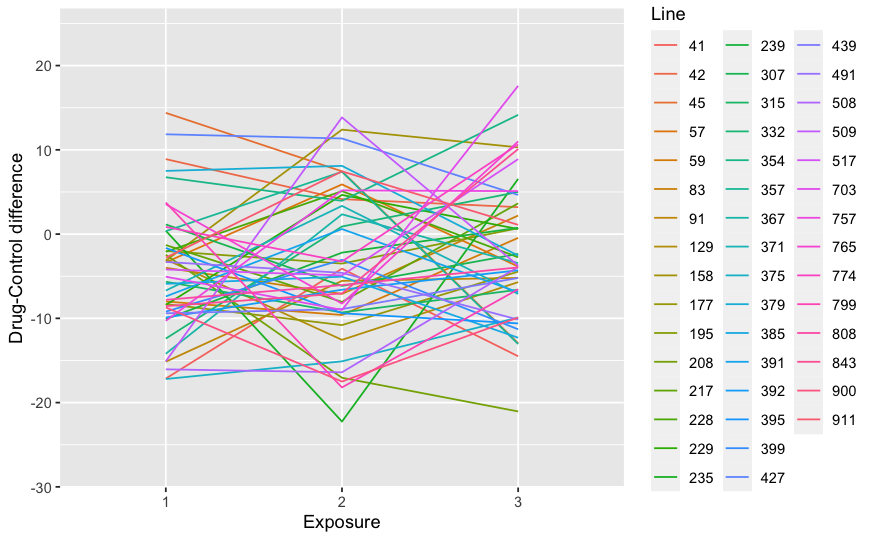

Can also look at other, line-independent effects among fixed factors. Most relevant is probably Sex*Solution*Exposure

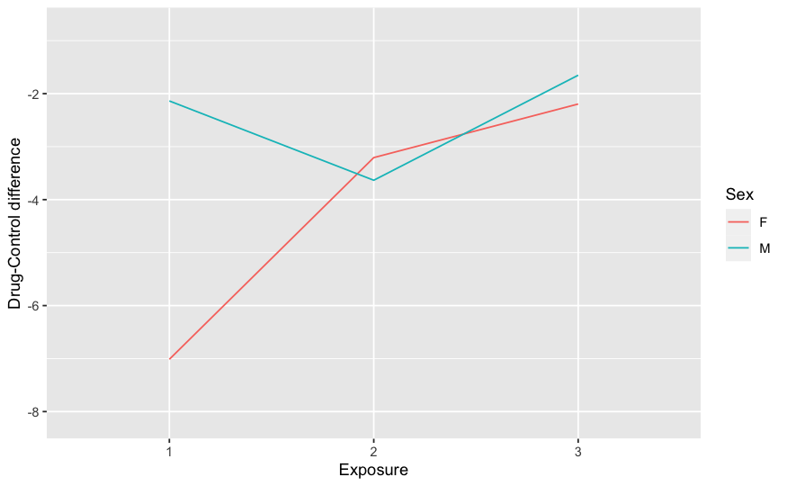

## References

Allen, R. M., and D. Marshall. 2014. “Egg Size Effects Across Multiple Life-History Stages in the Marine Annelid Hydroides Diramphus.” *PLoS One* 9 (7): e102253. https://doi.org/gf8mjs.

Highfill, Chad A., Brandon M. Baker, Stephenie D. Stevens, Robert R. H. Anholt, and Trudy F. C. Mackay. 2019. “Genetics of Cocaine and Methamphetamine Consumption and Preference in Drosophila Melanogaster.” *PLOS Genetics* 15 (5). https://doi.org/gr2pgk.

Kiffer, Walace P., Flavio Mendes, Cinthia G. Casotti, Larissa C. Costa, and Marcelo S. Moretti. 2018. “Exotic Eucalyptus Leaves Are Preferred over Tougher Native Species but Affect the Growth and Survival of Shredders in an Atlantic Forest Stream (Brazil).” Edited by Luiz U. Hepp. *PLOS ONE* 13 (1): e0190743. https://doi.org/gr9z2g.